# metadata cleaning

Yixuan Yang

2023-10-30

```r
rm(list = ls())
library(tidyverse)
library(here)
```

Here we start to explore the meta data form.

```r
meta_data <- readxl::read_xlsx(here('data/epilepsy_mapping.xlsx')) %>% arrange(str_rank(SampleID2, numeric = T))
meta_data <- meta_data[1:118,] # we had 124 obs, the last 6 obs are positive/negative control.
meta_data <- meta_data %>% arrange(str_rank(SampleID, numeric = T))
meta_data
```

```
## # A tibble: 118 × 12
##    SampleID SampleID2 `i7 Index ` `i7 sequence ` `i5 Index ` `i5 Sequence` Bag
##    <chr>    <chr>           <dbl> <chr>                <dbl> <chr>         <chr>
##  1 Netti_J  113               702 CGTACTAG               511 TCTCTCCG      54
##  2 Netti_J1 83                701 TAAGGCGA               502 CTCTCTAT      42
##  3 Netti_J2 87                701 TAAGGCGA               503 TATCCTCT      44
##  4 Netti_J3 20                701 TAAGGCGA               505 GTAAGGAG      10
##  5 Netti_J4 101               701 TAAGGCGA               506 ACTGCATA      51
##  6 Netti_J5 61                701 TAAGGCGA               507 AAGGAGTA      31
##  7 Netti_J6 2                 701 TAAGGCGA               508 CTAAGCCT      1
##  8 Netti_J7 15                701 TAAGGCGA               510 CGTCTAAT      8
##  9 Netti_J9 85                702 CGTACTAG               502 CTCTCTAT      43
## 10 Netti_J… 118               702 CGTACTAG               503 TATCCTCT      54
## # ℹ 108 more rows
## # ℹ 5 more variables: `Tube ` <chr>, `Dog Name` <chr>, Household <chr>,
## #   `Pheno or drug naive` <chr>, Group <chr>
```

Now, before we combine the meta data and the `dada2` results, we first take a look at the matching of sample ID. In the data, we see there are `SampleID` and `SampleID2`. We need to figure out which one is matching to the ID of the sequence files.

```r
# in this section, we are loading in the file names of each sequence file.
data.folder <- '~/Projects/Microbiome/CanineEpilepsy2/221024_UNC2X_KKYJ5-KKYGJ-NETTI-in/221024_UNC2X_KKYJ5-KKYGJ-NETTI'
fn.R1 <- list.files(data.folder, pattern = 'R1') %>% str_remove('_L001_R1_001.fastq.gz')
fn.R2 <- list.files(data.folder, pattern = 'R2') %>% str_remove('_L001_R2_001.fastq.gz')
# here we double check if there's any strange file names.
sum(fn.R1 != fn.R2)
```

```
## [1] 0
```

```r
# now split file names into ids and sequences
fn <- fn.R1 %>% str_split_fixed('_|-',3) %>% as.data.frame()
fn[,1] <- fn[,1] %>% str_remove('Netti')
sum(as.numeric(fn[,1]) == 1:118) # there's no strange number in file name
```

```
## [1] 118
```

Here, just by eye browsing, we can see if we arrange the metadata by `SampleID`, most of the i5 and i7 sequence does not match with that in file name.

```r
which(meta_data[,c(4,6)] != fn[,c(2,3)])
```

```
##   [1]   1   3   4   5   6   7   8   9  10  11  12  13  14  15  16  17  18  19
##  [19]  20  21  22  23  24  26  27  28  29  30  31  32  33  34  35  36  37  39
##  [37]  40  41  42  43  44  45  46  47  48  49  50  51  53  54  56  57  58  59
##  [55]  60  61  62  63  64  65  66  67  68  69  70  71  72  73  74  75  76  77
##  [73]  78  79  80  82  83  84  85  86  87  88  89  90  91  92  93  94  95  96
##  [91]  97  98  99 100 102 103 104 105 106 107 108 109 110 111 113 114 115 117
## [109] 118 119 120 121 122 123 124 125 126 127 128 129 131 132 134 135 136 137
## [127] 138 140 141 142 143 144 145 146 147 148 149 150 151 152 153 155 156 157
## [145] 158 159 160 161 162 163 164 165 166 167 168 169 170 171 172 173 174 175
## [163] 176 177 179 180 181 182 183 184 185 187 188 189 190 191 192 193 194 195
## [181] 196 197 198 199 201 202 203 204 205 206 207 208 209 210 211 212 213 215
## [199] 216 217 218 219 220 221 222 223 224 226 227 229 230 231 232 233 235 236
```

Moreover, we see one ‘Netti_J’ and two ‘Netti_J23’, but no ‘Netti_J8’ and ‘Netti_J112’, while they exist in the sequence file folder. There are also Netti_J 119, 120, 121 in `SampleID` and no #94,95,96, while they exist in file name. So `SampleID` is unlikely the sample thing in file name.

Here we start to match file name with sample id 2

```r
meta_data <- meta_data %>% arrange(str_rank(SampleID2, numeric = T))
which(meta_data$SampleID2 %>% as.numeric() %>% table() > 1)
```

```
## 104
## 103
```

The result shows that sample 104 appears more than 1 times. 103 is its index. From observation, sample 51 is missing.

```r
meta_data[c(103,104),]
```

```
## # A tibble: 2 × 12
##   SampleID  SampleID2 `i7 Index ` `i7 sequence ` `i5 Index ` `i5 Sequence` Bag
##   <chr>     <chr>           <dbl> <chr>                <dbl> <chr>         <chr>
## 1 Netti_J51 104               707 CTCTCTAC               505 GTAAGGAG      52
## 2 Netti_J51 104               707 CTCTCTAC               505 GTAAGGAG      52
## # ℹ 5 more variables: `Tube ` <chr>, `Dog Name` <chr>, Household <chr>,
## #   `Pheno or drug naive` <chr>, Group <chr>
```

```r
fn[104,]
```

```
##      V1       V2       V3
## 104 104 CTCTCTAC GTAAGGAG
```

Both sample id 104 have i7 and i5 sequence matching with that in file name. Bag, Tube and Dog Name are also same. However, the `Household` and `Group` are different. To keep exploring data, here we exclude the problematic data (sample 51 and 104 in both metadata and dada2 results)

```r
# sample 51 is removed when process the data (in script epi2.R)
meta_data_clean <- meta_data[-c(103,104),]
fn_clean <- fn[-c(51,104),]
which(meta_data_clean[,c(4,6)] != fn_clean[,c(2,3)]) # are all sequence match? print index if there's a difference.
```

```
## integer(0)
```

Now, we check if all data are paired.

```r
meta_data_clean$Household %>% as.numeric() %>% table()
```

```
## .
##  1  2  3  4  5  6  7  8  9 10 11 12 13 14 15 16 17 18 19 20 21 22 23 24 25 26
##  2  2  2  2  2  2  2  2  8  2  2  2  2  2  2  2  4  2  2  2  2  2  2  5  2  4
## 27 28 29 30 31 32 33 34 35 36 37 38 39 40 41 42 43 44 45 46 47 48 49 50 51 52
##  2  2  2  2  2  2  1  2  2  2  2  2  2  2  2  2  2  2  2  2  2  2  2  2  2  2
```

```r
which(meta_data_clean$Household %>% as.numeric() %>% table() %>% unname() != 2)
```

```
## [1]  9 17 24 26 33
```

Here, we see that household 9,17, 24, 26, 33 are not paired. Househould33 only have one data because we miss sample 51, which should also be in this household. According to the prior information, we know that household 17 and 26 contribute 4 dogs. household 9 and 24 contribute duplicated samples. Consider to remove the duplicate data after checking and compare their quality.

# Summary

With sample ID 51 and 104 removed, the meta data and data2 results could be matched by `SampleID2`. Other data should be considered removed after deeper analysis.

sample 52 should be removed if paired t test is needed.

sample 63,64, 113,115, 117,118 could be removed since they are duplicated samples. We can check their quality.

# Quality Assurance

```r
st <- readRDS(here('Rdata/following_study/st.rds'))
```

Do some QA on the sequencing libraries:

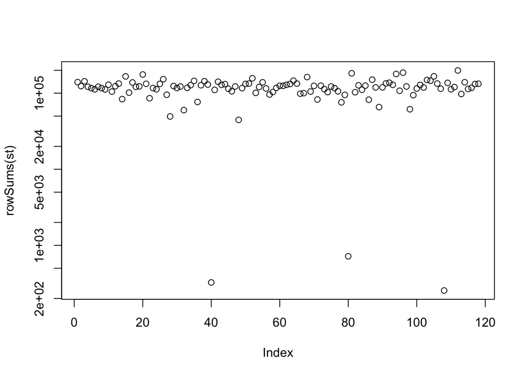

```r
plot(rowSums(st), log="y")
```

```r
which(rowSums(st) < 2e+3)
```

```
## Netti040 Netti080 Netti108
##       40       80      108
```

```r
which(rowSums(st) < 100)
```

```
## named integer(0)
```

All of the data has more than 100 reads, but sample 40,80 and 108 have relateively low # of reads.

sample 106,107,108 are duplicates of sample 103. Let’s look at their quality.

```r
rowSums(st)[c(103,106,107,108)]
```

```
## Netti103 Netti106 Netti107 Netti108
##   149299   133741   114520      255
```

Here we can keep sample 103 since it has more reads.

sample 63,113,115 are duplicates of sample 114. sample 64,117,118 are duplicates of sample 116.

```r
rowSums(st)[c(63,113,114,115)] %>% sort()
```

```
## Netti113 Netti115 Netti063 Netti114
##    97725   113687   132155   139269
```

```r
rowSums(st)[c(64,116,117,118)] %>% sort()
```

```
## Netti116 Netti117 Netti118 Netti064
##   117612   131987   133092   146129
```

Here we can keep the sample with most reads (sample 64 and 114)

# summary

For now we can remove sample 106,107,108,113,115,63,116,117,118.

```r
# remove sample 51 and 104 in st
st.new <- st[-c(51,104,106,107,108,113,115,63,116,117,118),]
# remove duplicates
meta_data.new <- meta_data[-c(103,104),] %>% filter(!(SampleID2 %in% as.character(c(106,107,108,113,115,63,116,117,118))))
if(!identical(rownames(st.new) %>% str_remove('Netti') %>% as.numeric(),
              meta_data.new$SampleID2 %>% as.numeric())) stop('sample id mismatch')
```

```r
which(meta_data.new$Household == 17)
```

```
## [1] 103 104 105 106
```

```r
meta_data.new[c(105,106),'Household'] = c('17_2', '17_2')
which(meta_data.new$Household == 26)
```

```
## [1] 25 26 37 38
```

```r
meta_data.new[c(38,37),]
```

```
## # A tibble: 2 × 12
##   SampleID  SampleID2 `i7 Index ` `i7 sequence ` `i5 Index ` `i5 Sequence` Bag
##   <chr>     <chr>           <dbl> <chr>                <dbl> <chr>         <chr>
## 1 Netti_J35 38                705 GGACTCCT               505 GTAAGGAG      19
## 2 Netti_J91 37                715 ATCTCAGG               505 GTAAGGAG      19
## # ℹ 5 more variables: `Tube ` <chr>, `Dog Name` <chr>, Household <chr>,
## #   `Pheno or drug naive` <chr>, Group <chr>
```

```r
meta_data.new[c(38,37),'Household'] = c('26_2', '26_2')
```

```r
which(meta_data.new$Household == 33)
```

```
## [1] 51
```

```r
st.new <- st.new[-51,]
meta_data.new <- meta_data.new[-51,]
```

```r
saveRDS(as.data.frame(meta_data.new), here('Rdata/following_study/metadata.rds'))
saveRDS(st.new, here('Rdata/following_study/st_new.rds'))
```